# R codebase（三）基础作图与ggplot2

Xiaohan

2022-02-09 22:31

> 段首语

此系列文章用来做R语言的学习，以及对于使用R语言进行数据处理和作图的代码汇总，方便大家随时进行查找、使用。

上一篇：R codebase (二) 数据转换

下一篇：R codebase (四) 基本数据分析

## 一、base R 基础作图

### 图形创建

- 颜色准备

```r
library(RColorBrewer)
```

- 直方图 histogram

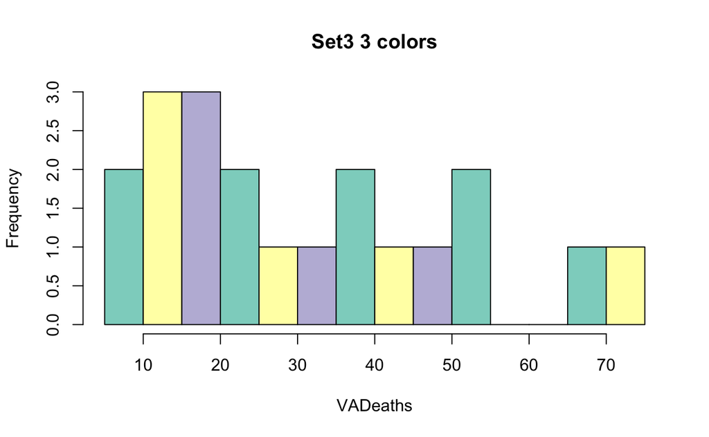

```r
data(VADeaths)
hist(VADeaths,breaks=10, col=brewer.pal(3,"Set3"),main="Set3 3 colors")
```

- 线性图 line chart

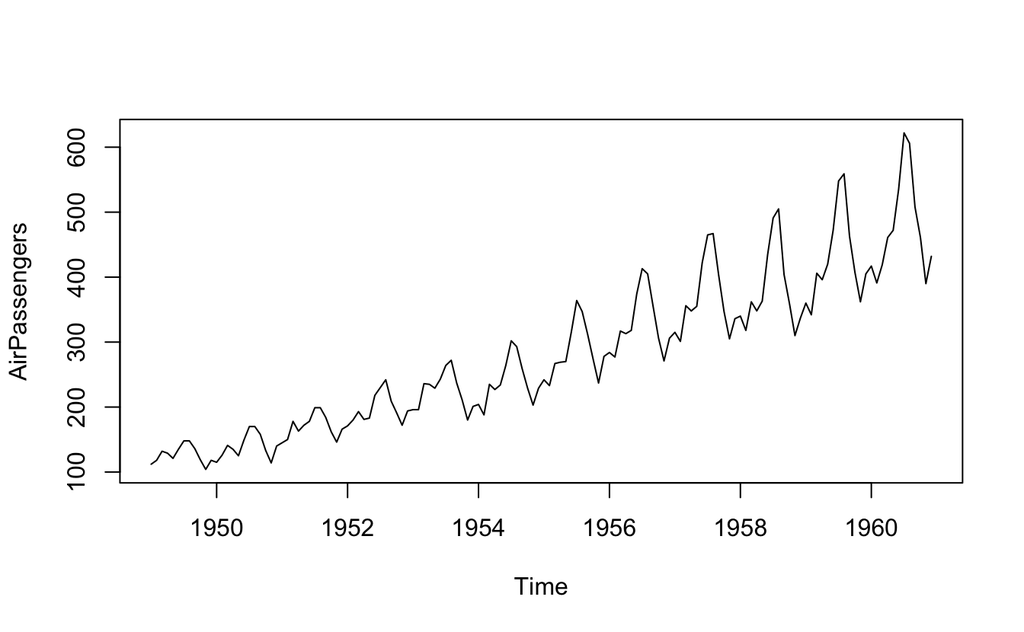

```r
plot(AirPassengers,type="l")
```

- 柱状图 bar chart

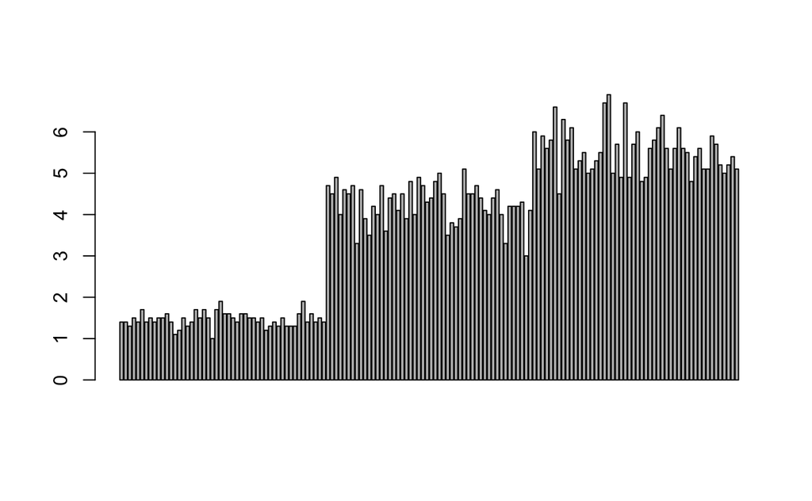

```r
barplot(iris$Petal.Length) #Creating simple Bar Graph
```

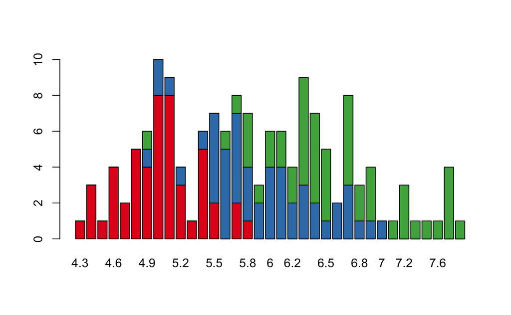

```r
barplot(table(iris$Species,iris$Sepal.Length),col = brewer.pal(3,"Set1"))
```

- 盒形图 boxplot

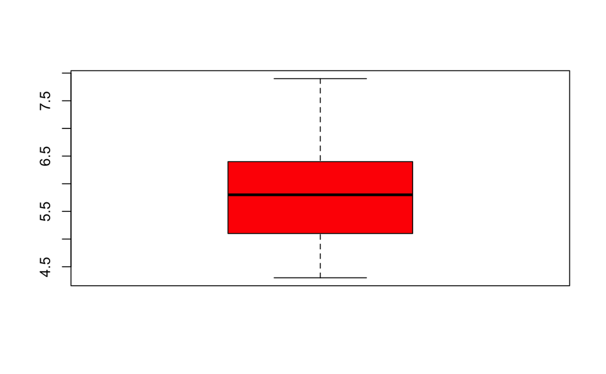

```r
data(iris)
boxplot(iris$Sepal.Length,col="red")
```

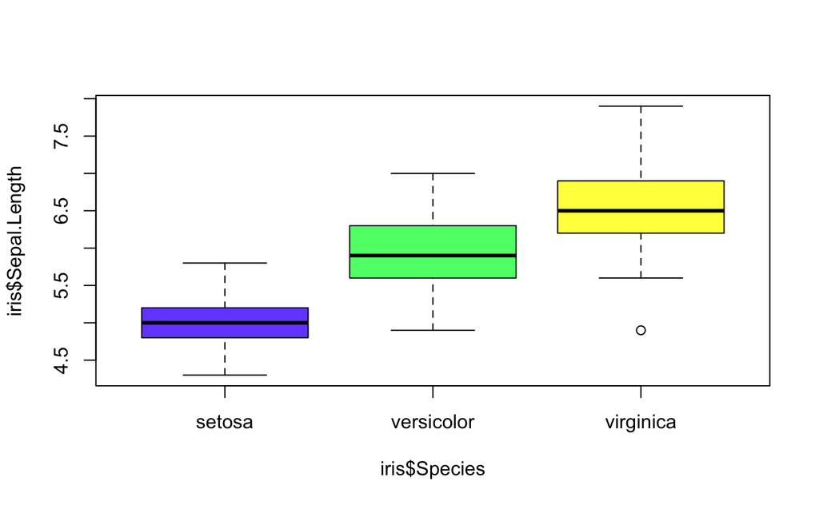

```r
boxplot(iris$Sepal.Length~iris$Species,col=topo.colors(3,alpha = 0.8))
```

- 散点图

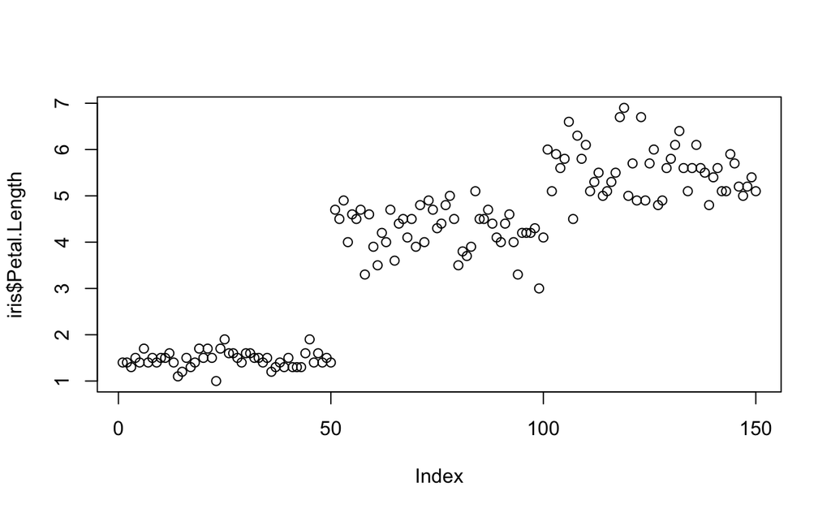

```r
plot(x=iris$Petal.Length)
```

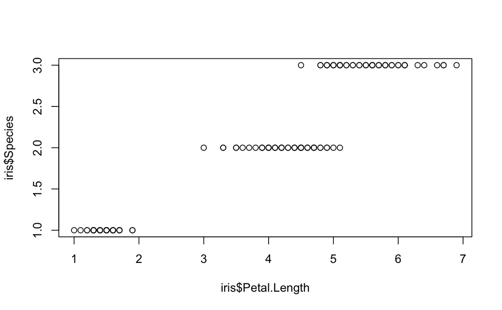

```r
plot(x=iris$Petal.Length,y=iris$Species)
```

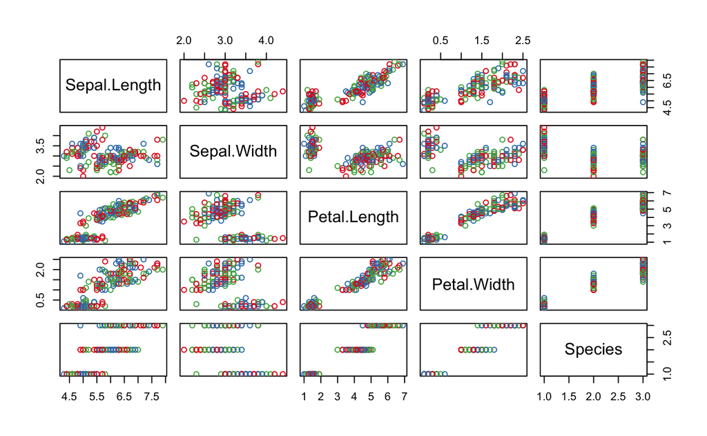

```r
plot(iris,col=brewer.pal(3,"Set1"))
```

- 六边形密度图 Hexbin Binning

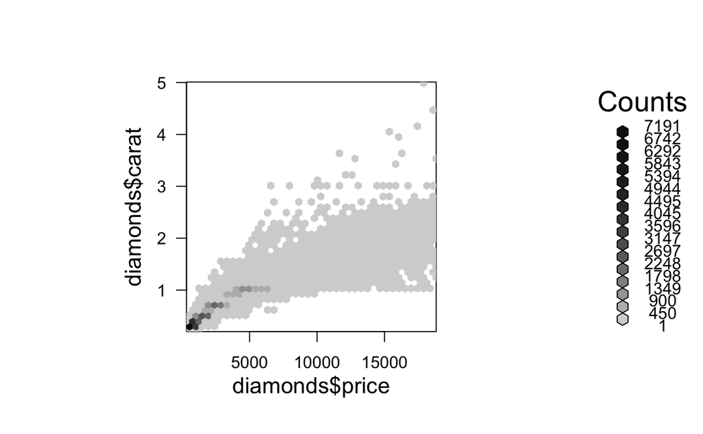

```r
library(hexbin)
library(ggplot2)
diamonds <- diamonds
a=hexbin(diamonds$price,diamonds$carat,xbins=40)
plot(a)
```

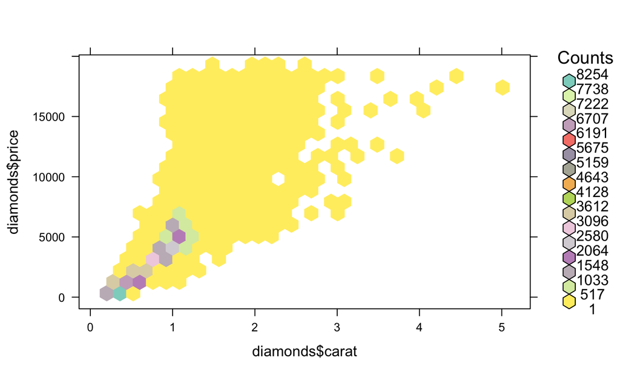

```r
rf <- colorRampPalette(rev(brewer.pal(40,'Set3')))
## Warning in brewer.pal(40, "Set3"): n too large, allowed maximum for palette Set3 is 12
## Returning the palette you asked for with that many colors
hexbinplot(diamonds$price~diamonds$carat, data=diamonds, colramp=rf)
```

*马赛克图（Mosaic Plot），也叫做不等宽柱状图(Marimekko Chart)

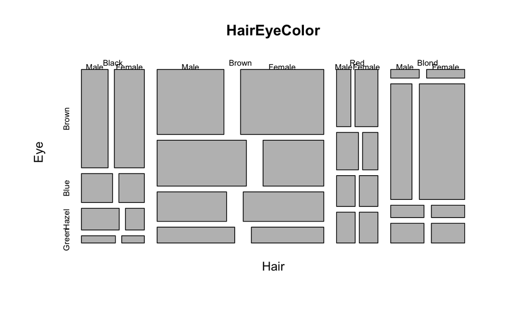

```r
data(HairEyeColor)
mosaicplot(HairEyeColor)
```

- 热图

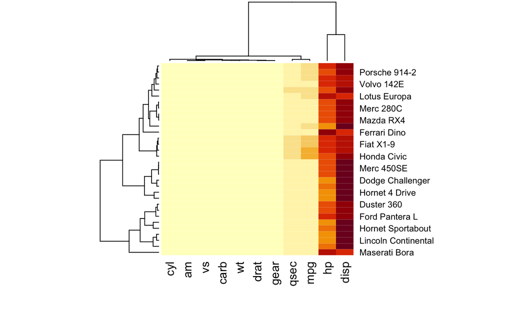

```r
head(mtcars)
##                    mpg cyl disp  hp drat    wt  qsec vs am gear carb
## Mazda RX4         21.0   6  160 110 3.90 2.620 16.46  0  1    4    4
## Mazda RX4 Wag     21.0   6  160 110 3.90 2.875 17.02  0  1    4    4
## Datsun 710        22.8   4  108  93 3.85 2.320 18.61  1  1    4    1
## Hornet 4 Drive    21.4   6  258 110 3.08 3.215 19.44  1  0    3    1
## Hornet Sportabout 18.7   8  360 175 3.15 3.440 17.02  0  0    3    2
## Valiant           18.1   6  225 105 2.76 3.460 20.22  1  0    3    1
heatmap(as.matrix(mtcars))
```

* 地图 Map

```r
## devtools::install_github("rstudio/leaflet")
library(magrittr)
## Warning: package 'magrittr' was built under R version 4.0.5
library(leaflet)
m <- leaflet() %>%
  addTiles() %>% # Add default OpenStreetMap map tiles
  addMarkers(lng=77.2310, lat=28.6560, popup="food of chandni chowk")
m
```

[interactive chart not shown]

- 3D

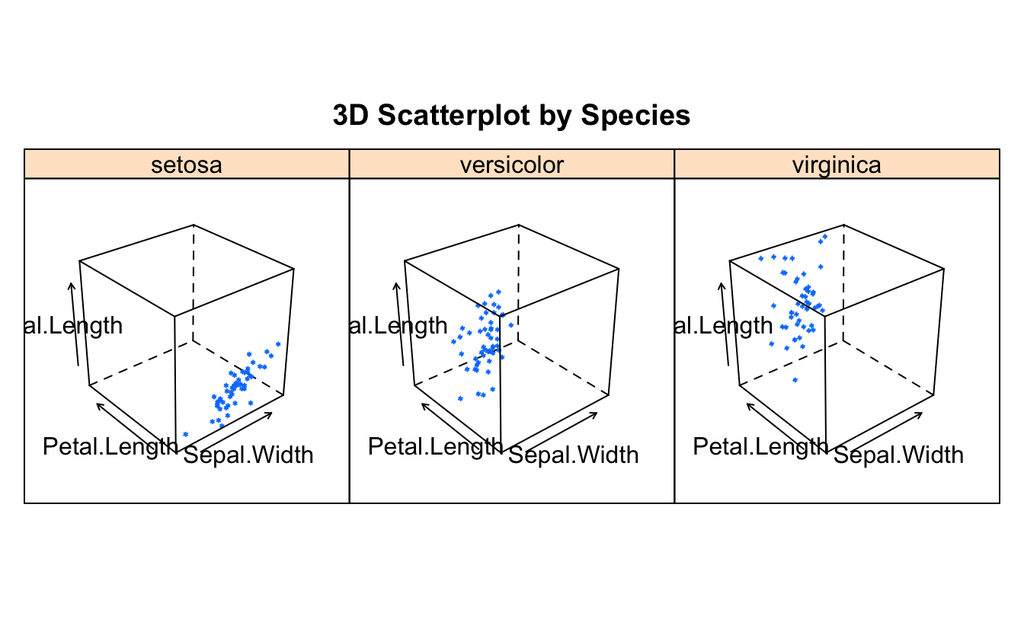

```r
data(iris, package="datasets")
library(car)
## Loading required package: carData
# scatter3d(Petal.Width~Petal.Length+Sepal.Length|Species, data=iris, fit="linear",residuals=TRUE, parallel=FALSE, bg="black", axis.scales=TRUE, grid=TRUE, ellipsoid=FALSE)

library(lattice)
attach(iris)# 3d scatterplot by factor level
  cloud(Sepal.Length~Sepal.Width*Petal.Length|Species, main="3D Scatterplot by Species")
```

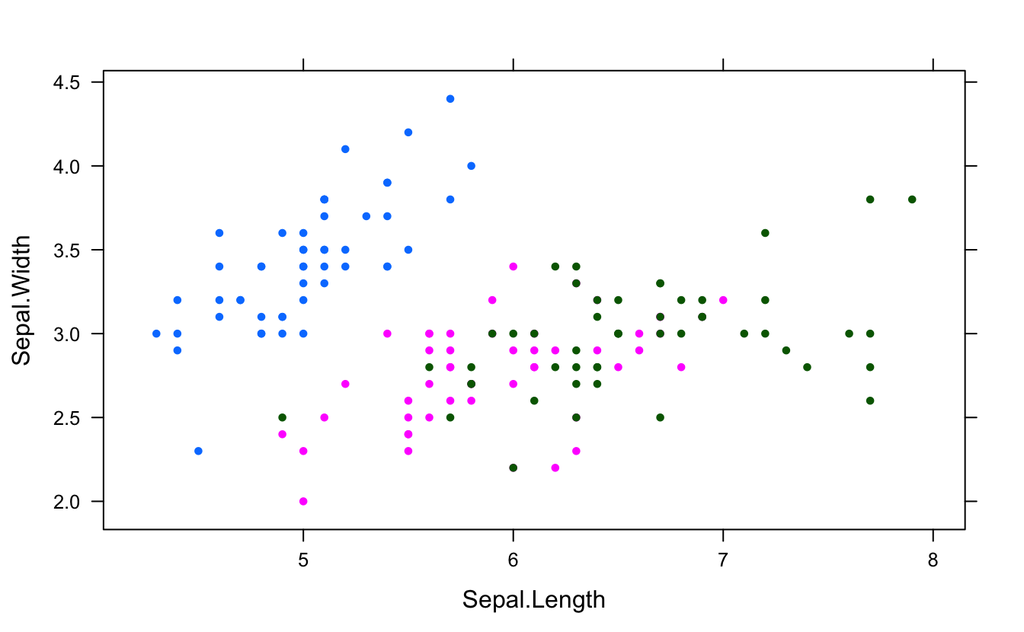

```r
  xyplot(Sepal.Width ~ Sepal.Length, iris, groups = iris$Species, pch= 20)
```

* 相关性图 Correlogram (GUIs)

[figure not shown]

```r
cor(iris[1:4])
##              Sepal.Length Sepal.Width Petal.Length Petal.Width
## Sepal.Length    1.0000000  -0.1175698    0.8717538   0.8179411
## Sepal.Width    -0.1175698   1.0000000   -0.4284401  -0.3661259
## Petal.Length    0.8717538  -0.4284401    1.0000000   0.9628654
## Petal.Width     0.8179411  -0.3661259    0.9628654   1.0000000
library(corrgram)
##
## Attaching package: 'corrgram'
## The following object is masked from 'package:lattice':
##
##     panel.fill
corrgram(iris)
```

### 图形定制

#### 1.字符、文本

- 文字大小

| 参数 | 描述 |
| --- | --- |
| cex | 相对于默认大小的缩放倍数 |
| cex.axis | 坐标轴刻度文字的缩放倍数 |
| cex.lab | 坐标轴标签的缩放倍数 |
| cex.main | 标题的缩放倍数 |
| cex.sub | 副标题的缩放倍数 |

- 文字字体

| 参数 | 描述 |
| --- | --- |
| font | 用于指定绘图所用的字体样式。1=常规，2=粗体，3=斜体，4=粗斜体，5=符号字体（以Adobe符号编码表示） |
| font.axis | 坐标轴刻度字体样式 |
| font.lab | 坐标轴标签字体样式 |
| font.main | 标题的字体样式 |
| font.sub | 副标题的字体样式 |
| ps | 字体磅值，文本的最终大小为ps*cex |
| family | 绘制文本时使用的字体族，serif(衬线),sans(无衬线),mono(等宽) |

#### 2.符号和线条

| 参数 | 描述 |
| --- | --- |
| pch | 符号类型 |
| cex | 符号大小 |
| lty | 线条类型 |
| lwd | 线条宽度 |

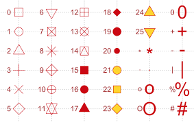

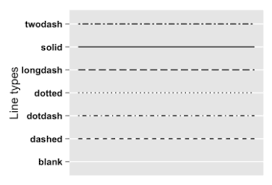

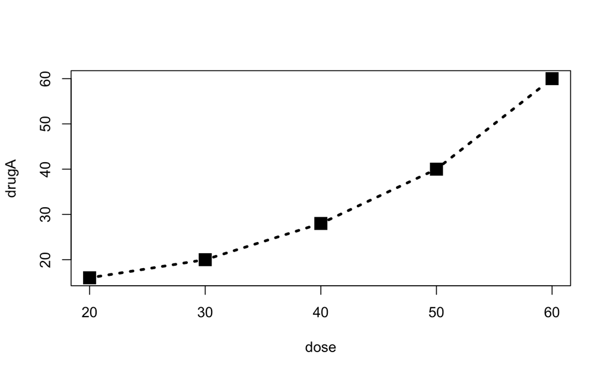

```r
dose <- c(20,30,40,50,60)
drugA <- c(16,20,28,40,60)
plot(dose,drugA,type = "b",lty=3,lwd=3,pch=15,cex=2)
```